# Metagenomics Downstream Analysis

Diversity analysis of the gut microbiome in Malawian adults

Youssef

2026-09-28

## Data Loading

### Metadata

```r
# Read sample metadata
metadata <- read.csv("../data/metadata.csv")

# Keep only relevant columns
metadata <- metadata[, c("Run", "pid", "visit", "t", "sample_type",
                          "arm_x", "ESBL", "calc_age", "ptsex", "hivstatus")]

# Quick check
dim(metadata)
```

```
## [1] 24 10
```

```r
head(metadata[, c("Run", "pid", "visit", "t", "sample_type")])
```

```
##           Run      pid visit  t sample_type
## 1 ERR14760456 DAS1021V     1  7       stool
## 2 ERR14760457 DAS1014T     1  7       stool
## 3 ERR14760458 DAS1020X     1  7       stool
## 4 ERR14760460 DAS1005V     0  0       stool
## 5 ERR14760461 DAS10020     0  0 rectal_swab
## 6 ERR14760582 DAS1021V     2 28       stool
```

### Bracken files

```r
# List all bracken files
bracken_files <- list.files("../data/bracken/",
                             pattern = "\\.bracken$",
                             full.names = TRUE)

# Function to read one bracken file
read_bracken <- function(f) {
  df <- read.delim(f, sep = "\t", header = TRUE, stringsAsFactors = FALSE)
  df$Sample <- sub("\\.bracken$", "", basename(f))
  df <- df[, c("Sample", "name", "taxonomy_id", "taxonomy_lvl",
               "kraken_assigned_reads", "added_reads",
               "new_est_reads", "fraction_total_reads")]
  return(df)
}

# Read and merge all files
bracken_all <- do.call(rbind, lapply(bracken_files, read_bracken))

# Check
dim(bracken_all)
```

```
## [1] 181428      8
```

```r
head(bracken_all)
```

```
##        Sample                      name taxonomy_id taxonomy_lvl
## 1 ERR14760456       Veillonella parvula       29466            S
## 2 ERR14760456        Veillonella dispar       39778            S
## 3 ERR14760456       Veillonella rogosae      423477            S
## 4 ERR14760456 Veillonella sp. S12025-13     2682455            S
## 5 ERR14760456     Veillonella nakazawae     2682456            S
## 6 ERR14760456       Veillonella atypica       39777            S
##   kraken_assigned_reads added_reads new_est_reads fraction_total_reads
## 1               9838720      398979      10237699              0.30098
## 2               3610979      904755       4515734              0.13276
## 3               1156226      104455       1260681              0.03706
## 4               1037123      430989       1468112              0.04316
## 5                881092      459402       1340494              0.03941
## 6                384795       11741        396536              0.01166
```

## Community Matrix

We build a samples × species matrix using `new_est_reads` (Bracken-corrected abundances).

```r
# Build samples × species matrix
comm_matrix <- bracken_all %>%
  select(Sample, name, new_est_reads) %>%
  pivot_wider(names_from = name,
              values_from = new_est_reads,
              values_fill = 0)

# Convert to data frame and set row names
comm_matrix <- as.data.frame(comm_matrix)
rownames(comm_matrix) <- comm_matrix$Sample
comm_matrix$Sample <- NULL

# Check dimensions
dim(comm_matrix)
```

```
## [1]    24 11206
```

```r
comm_matrix[1:5, 1:5]
```

```
##             Veillonella parvula Veillonella dispar Veillonella rogosae
## ERR14760456            10237699            4515734             1260681
## ERR14760457                 358                136                 854
## ERR14760458                1704                367                 550
## ERR14760460              233425              54934               53680
## ERR14760461               45271              11803                7553
##             Veillonella sp. S12025-13 Veillonella nakazawae
## ERR14760456                   1468112               1340494
## ERR14760457                        95                    77
## ERR14760458                       198                   182
## ERR14760460                     22790                 24979
## ERR14760461                      5273                  4438
```

The matrix contains **24 samples** and **11206 species**.

## Alpha Diversity

```r
# Compute alpha diversity metrics
alpha_div <- data.frame(
  Sample     = rownames(comm_matrix),
  Observed   = specnumber(comm_matrix),
  Shannon    = diversity(comm_matrix, index = "shannon"),
  Simpson    = diversity(comm_matrix, index = "simpson"),
  InvSimpson = diversity(comm_matrix, index = "invsimpson"),
  Chao1      = estimateR(comm_matrix)["S.chao1", ]
)

# Check
dim(alpha_div)
```

```
## [1] 24  6
```

```r
head(alpha_div)
```

```
##                  Sample Observed  Shannon   Simpson InvSimpson Chao1
## ERR14760456 ERR14760456     3459 3.018689 0.8747009   7.980904  3459
## ERR14760457 ERR14760457     4096 2.303139 0.7938833   4.851621  4096
## ERR14760458 ERR14760458     8907 4.214115 0.9587036  24.215181  8907
## ERR14760460 ERR14760460     7147 4.116929 0.9486143  19.460671  7147
## ERR14760461 ERR14760461     8947 4.446521 0.9652077  28.742006  8947
## ERR14760582 ERR14760582     8942 5.077984 0.9593814  24.619265  8942
```

### Merge with metadata

```r
# Merge alpha diversity with sample metadata
alpha_meta <- merge(alpha_div,
                    metadata[, c("Run", "pid", "visit", "t", "sample_type")],
                    by.x = "Sample", by.y = "Run")

# Check
dim(alpha_meta)
```

```
## [1] 24 10
```

```r
head(alpha_meta)
```

```
##        Sample Observed  Shannon   Simpson InvSimpson Chao1      pid visit  t
## 1 ERR14760456     3459 3.018689 0.8747009   7.980904  3459 DAS1021V     1  7
## 2 ERR14760457     4096 2.303139 0.7938833   4.851621  4096 DAS1014T     1  7
## 3 ERR14760458     8907 4.214115 0.9587036  24.215181  8907 DAS1020X     1  7
## 4 ERR14760460     7147 4.116929 0.9486143  19.460671  7147 DAS1005V     0  0
## 5 ERR14760461     8947 4.446521 0.9652077  28.742006  8947 DAS10020     0  0
## 6 ERR14760582     8942 5.077984 0.9593814  24.619265  8942 DAS1021V     2 28
##   sample_type
## 1       stool
## 2       stool
## 3       stool
## 4       stool
## 5 rectal_swab
## 6       stool
```

### Shannon Diversity by Visit

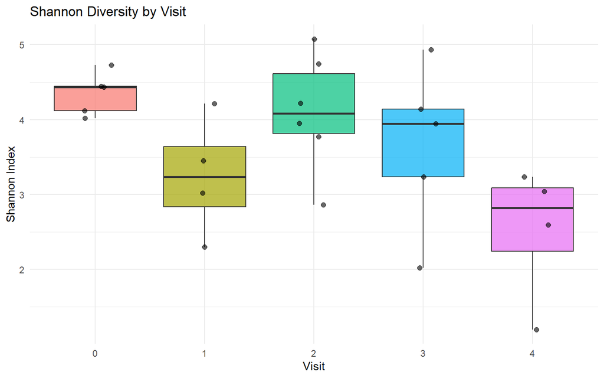

```r
# Convert visit to factor for proper ordering
alpha_meta$visit_f <- factor(alpha_meta$visit)

ggplot(alpha_meta, aes(x = visit_f, y = Shannon, fill = visit_f)) +
  geom_boxplot(alpha = 0.7) +
  geom_jitter(width = 0.15, size = 2, alpha = 0.6) +
  labs(
    title = "Shannon Diversity by Visit",
    x = "Visit",
    y = "Shannon Index"
  ) +
  theme(legend.position = "none")
```

### Shannon Diversity over Time — All Patients

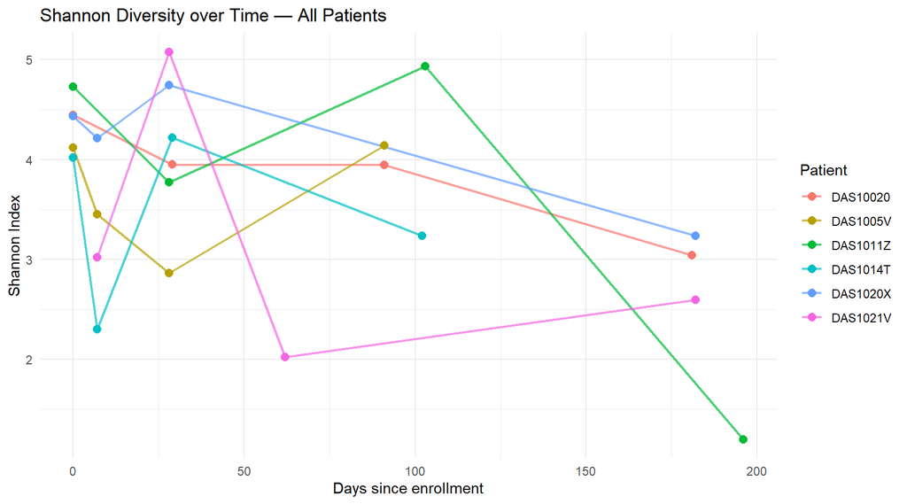

```r
ggplot(alpha_meta, aes(x = t, y = Shannon, color = pid, group = pid)) +
  geom_line(size = 0.8, alpha = 0.7) +
  geom_point(size = 2.5) +
  labs(
    title = "Shannon Diversity over Time — All Patients",
    x = "Days since enrollment",
    y = "Shannon Index",
    color = "Patient"
  )
```

### Per-Patient Trajectories

To investigate individual patterns, we plot the trajectory of each patient separately.

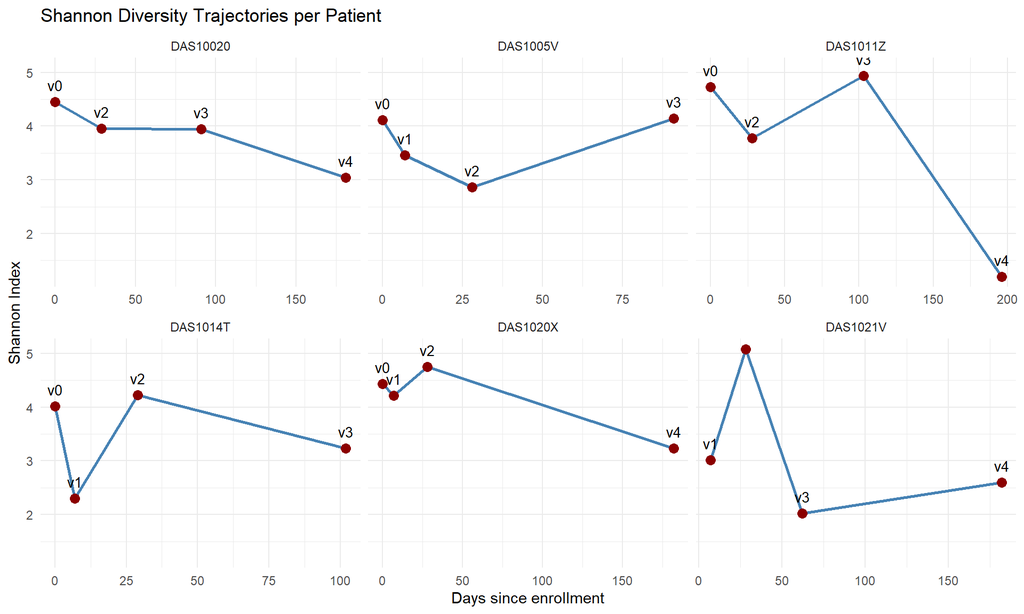

```r
ggplot(alpha_meta, aes(x = t, y = Shannon)) +
  geom_line(color = "steelblue", size = 1) +
  geom_point(size = 3, color = "darkred") +
  geom_text(aes(label = paste0("v", visit)), vjust = -1, size = 3.5) +
  facet_wrap(~ pid, ncol = 3, scales = "free_x") +
  labs(
    title = "Shannon Diversity Trajectories per Patient",
    x = "Days since enrollment",
    y = "Shannon Index"
  )
```

## Beta Diversity

Beta diversity quantifies differences **between** samples. We use the Bray-Curtis distance, which is standard for microbiome data.

```r
# Compute Bray-Curtis distance matrix
bc_dist <- vegdist(comm_matrix, method = "bray")

# Check
class(bc_dist)
```

```
## [1] "dist"
```

### PCoA Ordination

Principal Coordinates Analysis (PCoA) projects samples into 2D space based on their Bray-Curtis distances.

```r
# Run PCoA
pcoa_res <- cmdscale(bc_dist, k = 2, eig = TRUE)

# Variance explained by each axis
var_explained <- round(pcoa_res$eig[1:2] /
                       sum(pcoa_res$eig[pcoa_res$eig > 0]) * 100, 1)

# Extract coordinates
pcoa_df <- data.frame(
  Sample = rownames(pcoa_res$points),
  PC1    = pcoa_res$points[, 1],
  PC2    = pcoa_res$points[, 2]
)

# Merge with metadata
pcoa_df <- merge(pcoa_df,
                 metadata[, c("Run", "pid", "visit", "t", "sample_type")],
                 by.x = "Sample", by.y = "Run")

pcoa_df$visit_f <- factor(pcoa_df$visit)

head(pcoa_df)
```

```
##        Sample          PC1         PC2      pid visit  t sample_type visit_f
## 1 ERR14760456 -0.445255252 -0.15219798 DAS1021V     1  7       stool       1
## 2 ERR14760457 -0.253081376  0.28461542 DAS1014T     1  7       stool       1
## 3 ERR14760458  0.184141064  0.06084008 DAS1020X     1  7       stool       1
## 4 ERR14760460 -0.267012769 -0.32173122 DAS1005V     0  0       stool       0
## 5 ERR14760461  0.009038195 -0.10172997 DAS10020     0  0 rectal_swab       0
## 6 ERR14760582  0.233982591 -0.05990413 DAS1021V     2 28       stool       2
```

### PCoA — Colored by Patient

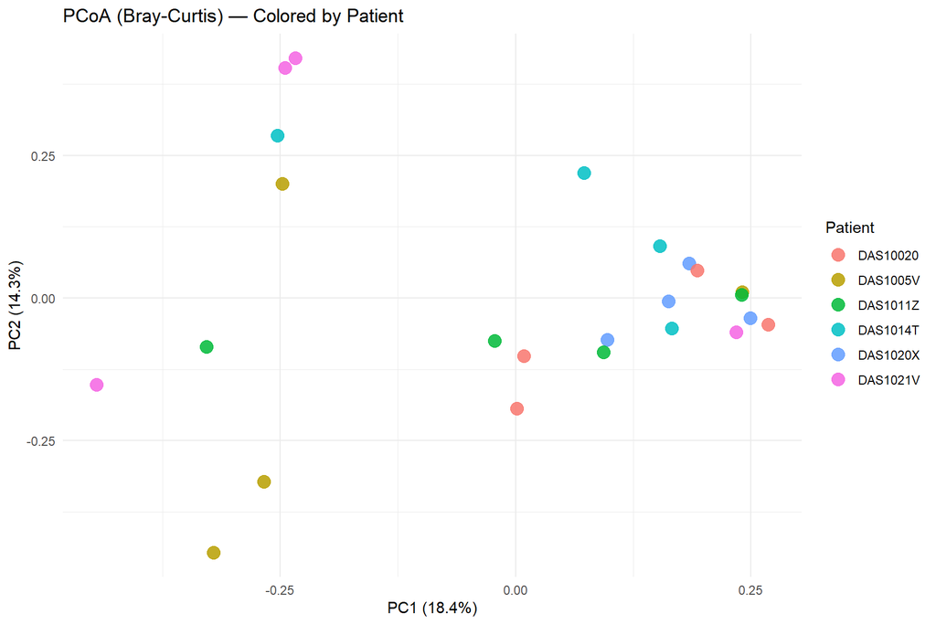

```r
ggplot(pcoa_df, aes(x = PC1, y = PC2, color = pid)) +
  geom_point(size = 4, alpha = 0.85) +
  labs(
    title = "PCoA (Bray-Curtis) — Colored by Patient",
    x = paste0("PC1 (", var_explained[1], "%)"),
    y = paste0("PC2 (", var_explained[2], "%)"),
    color = "Patient"
  )
```

### PCoA — Colored by Visit

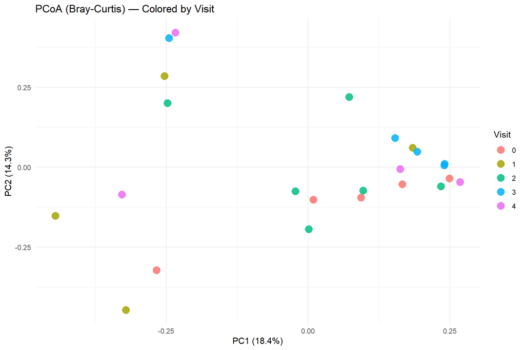

```r
ggplot(pcoa_df, aes(x = PC1, y = PC2, color = visit_f)) +
  geom_point(size = 4, alpha = 0.85) +
  labs(
    title = "PCoA (Bray-Curtis) — Colored by Visit",
    x = paste0("PC1 (", var_explained[1], "%)"),
    y = paste0("PC2 (", var_explained[2], "%)"),
    color = "Visit"
  )
```

The two plots show that samples tend to cluster more strongly by **patient** than by **visit**, suggesting that host-specific factors dominate over antibiotic-driven temporal shifts in this pilot.

## Statistical Testing

To test whether microbiome composition differs significantly by **visit** or by **patient**, we run PERMANOVA (adonis2) on the Bray-Curtis distance matrix.

### PERMANOVA — Visit

```r
permanova_visit <- adonis2(bc_dist ~ visit,
                           data = pcoa_df,
                           permutations = 999)
permanova_visit
```

```
## Permutation test for adonis under reduced model
## Permutation: free
## Number of permutations: 999
##
## adonis2(formula = bc_dist ~ visit, data = pcoa_df, permutations = 999)
##          Df SumOfSqs      R2      F Pr(>F)
## Model     1   0.4145 0.06364 1.4953  0.086 .
## Residual 22   6.0991 0.93636
## Total    23   6.5136 1.00000
## ---
## Signif. codes:  0 '***' 0.001 '**' 0.01 '*' 0.05 '.' 0.1 ' ' 1
```

### PERMANOVA — Patient

```r
permanova_patient <- adonis2(bc_dist ~ pid,
                             data = pcoa_df,
                             permutations = 999)
permanova_patient
```

```
## Permutation test for adonis under reduced model
## Permutation: free
## Number of permutations: 999
##
## adonis2(formula = bc_dist ~ pid, data = pcoa_df, permutations = 999)
##          Df SumOfSqs      R2      F Pr(>F)
## Model     5   1.9755 0.30329 1.5671  0.002 **
## Residual 18   4.5381 0.69671
## Total    23   6.5136 1.00000
## ---
## Signif. codes:  0 '***' 0.001 '**' 0.01 '*' 0.05 '.' 0.1 ' ' 1
```

### Interpretation

```r
# Extract R² and p-values as simple variables
visit_r2  <- round(permanova_visit$R2[1] * 100, 1)
visit_p   <- round(permanova_visit$`Pr(>F)`[1], 3)
patient_r2 <- round(permanova_patient$R2[1] * 100, 1)
patient_p  <- round(permanova_patient$`Pr(>F)`[1], 3)
```

**Visit** explains only **6.4%** of the variance (p = 0.086), whereas **Patient** explains **30.3%** (p = 0.002).

This indicates that **host-specific factors** dominate microbiome composition, while short-term antibiotic exposure has a weaker (and non-significant) effect in this small pilot (n = 6 patients, 24 samples).

## Save Results

We save the main tables and figures so they can be reused or shared.

```r
# Save alpha diversity table
write.csv(alpha_meta,
          "../results/alpha_diversity.csv",
          row.names = FALSE)

# Save beta diversity coordinates
write.csv(pcoa_df,
          "../results/beta_diversity_pcoa.csv",
          row.names = FALSE)

# Save PERMANOVA results
permanova_summary <- data.frame(
  Factor    = c("Visit", "Patient"),
  R2_percent = c(visit_r2, patient_r2),
  p_value    = c(visit_p, patient_p)
)
write.csv(permanova_summary,
          "../results/permanova_summary.csv",
          row.names = FALSE)

cat("Results saved successfully.\n")
```

```
## Results saved successfully.
```